# Intro to Stats in R

# load libraries

```r
library(palmerpenguins)
library(ggpubr)
library(jmv)
library(rstatix)
library(tidyverse)
library(here)
library(janitor)
library(ggeasy)
library(readxl)
library(gt)
library(haven)
require(gridExtra)
library(gtsummary)

theme_set(theme_bw())
```

# Stats in R using penguins dataset

# Example 1a: Are male penguins heavier than female penguins? (categorical and continuous - 2 groups: male and female)

### descriptive statistics

```r
penguins <- penguins %>%
  na.omit()

body_mass_summary <- penguins %>%
  group_by(sex) %>%
  summarise(mean = mean(body_mass_g),
            sd = sd(body_mass_g),
            n = n(),
            se = sd/sqrt(n))

body_mass_summary %>%
  gt() %>%
  fmt_number(
    columns = 2:5,
    decimals = 2
  )
```

| sex | mean | sd | n | se |
| --- | --- | --- | --- | --- |
| female | 3,862.27 | 666.17 | 165.00 | 51.86 |
| male | 4,545.68 | 787.63 | 168.00 | 60.77 |

### visualization

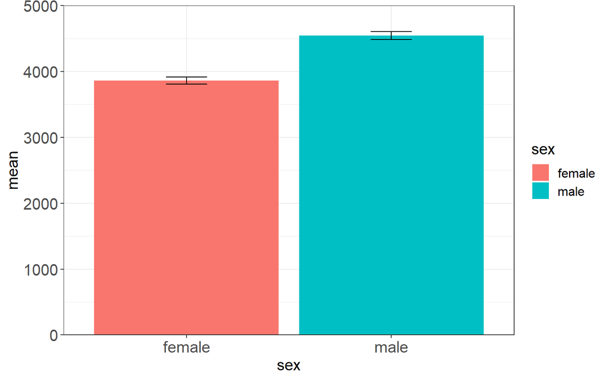

```r
# bar plot
body_mass_summary %>%
  ggplot(aes(x = sex, y = mean, fill = sex)) +
  geom_col() +
  geom_errorbar(aes(ymin = mean - se, ymax = mean + se),
                width=.2) +
  scale_y_continuous(expand = c(0,0), limits = c(0,5000)) + # no white space between 0 and x axis
  easy_text_size(15)
```

```r
# boxplot
plot_1a <- penguins %>%
  na.omit() %>%
  group_by(sex) %>%
  ggplot(aes(x = sex, y = body_mass_g, fill = sex)) +
  geom_boxplot(alpha = 0.5) +
  geom_jitter(alpha = 0.8) +
  easy_text_size(15)
```

### statistics: we want to compare means between 2 groups… t test

```r
female <- penguins %>%
  filter(sex == "female")

male <- penguins %>%
  filter(sex == "male")

t.test(female$body_mass_g, male$body_mass_g)
```

```
##
##  Welch Two Sample t-test
##
## data:  female$body_mass_g and male$body_mass_g
## t = -8.5545, df = 323.9, p-value = 4.794e-16
## alternative hypothesis: true difference in means is not equal to 0
## 95 percent confidence interval:
##  -840.5783 -526.2453
## sample estimates:
## mean of x mean of y
##  3862.273  4545.685
```

```r
# or we can use jmv package
ttestIS(formula = body_mass_g ~ sex, data = penguins) # independent samples t test. Dependent variable to the left of ~
```

```
##
##  INDEPENDENT SAMPLES T-TEST
##
##  Independent Samples T-Test
##  -----------------------------------------------------------------------
##                                  Statistic      df          p
##  -----------------------------------------------------------------------
##    body_mass_g    Student's t    -8.541720 ᵃ    331.0000    < .0000001
##  -----------------------------------------------------------------------
##    ᵃ Levene's test is significant (p < .05), suggesting a violation
##    of the assumption of equal variances
```

### ggpubr: “publication ready”

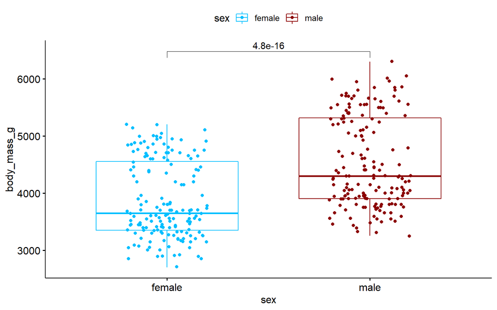

```r
plot_1a_pub <- ggboxplot(penguins, x = "sex", y = "body_mass_g",
                color = "sex", palette =c("deepskyblue", "darkred"),
                add = "jitter")

my_comparisons <- list(c("female", "male")) # has to be in a list
plot_1a_pub +
  stat_compare_means(comparisons = my_comparisons, method="t.test")
```

```r
# Add t.test comparisons p-value (if more than 2 groups, you can "anova")
```

# Example 1b: Do different species have the same or different overall weight? (categorical and continuous - 3 groups)

https://www.datanovia.com/en/lessons/anova-in-r/

### descriptive statistics

```r
penguins <- penguins %>%
  na.omit()

body_mass_summary <- penguins %>%
  group_by(species) %>%
  summarise(mean = mean(body_mass_g),
            sd = sd(body_mass_g),
            n = n(),
            se = sd/sqrt(n))

body_mass_summary %>%
  gt()
```

| species | mean | sd | n | se |
| --- | --- | --- | --- | --- |
| Adelie | 3706.164 | 458.6201 | 146 | 37.95567 |
| Chinstrap | 3733.088 | 384.3351 | 68 | 46.60747 |
| Gentoo | 5092.437 | 501.4762 | 119 | 45.97024 |

```r
penguins %>%
  group_by(species) %>%
  get_summary_stats(body_mass_g, type = "full")
```

```
## # A tibble: 3 x 14
##   species  variable     n   min   max median    q1    q3   iqr   mad  mean    sd
##   <fct>    <chr>    <dbl> <dbl> <dbl>  <dbl> <dbl> <dbl> <dbl> <dbl> <dbl> <dbl>
## 1 Adelie   body_ma~   146  2850  4775   3700 3362.  4000  638.  445. 3706.  459.
## 2 Chinstr~ body_ma~    68  2700  4800   3700 3488.  3950  462.  371. 3733.  384.
## 3 Gentoo   body_ma~   119  3950  6300   5050 4700   5500  800   593. 5092.  501.
## # ... with 2 more variables: se <dbl>, ci <dbl>
```

```r
penguins %>%
  group_by(species) %>%
  identify_outliers(body_mass_g)
```

```
## # A tibble: 2 x 10
##   species island bill_length_mm bill_depth_mm flipper_length_~ body_mass_g sex
##   <fct>   <fct>           <dbl>         <dbl>            <int>       <int> <fct>
## 1 Chinst~ Dream            52            20.7              210        4800 male
## 2 Chinst~ Dream            46.9          16.6              192        2700 fema~
## # ... with 3 more variables: year <int>, is.outlier <lgl>, is.extreme <lgl>
```

### visualization

```r
# identical code as in example 1a but now species rather than sex

plot_1b <- penguins %>%
  na.omit() %>%
  group_by(species) %>%
  ggplot(aes(x = species, y = body_mass_g, fill = species)) +
  geom_boxplot(alpha = 0.5) +
  geom_jitter(alpha = 0.8) +
  easy_text_size(15)
```

### statistics: we want to compare means between 3 groups… anova

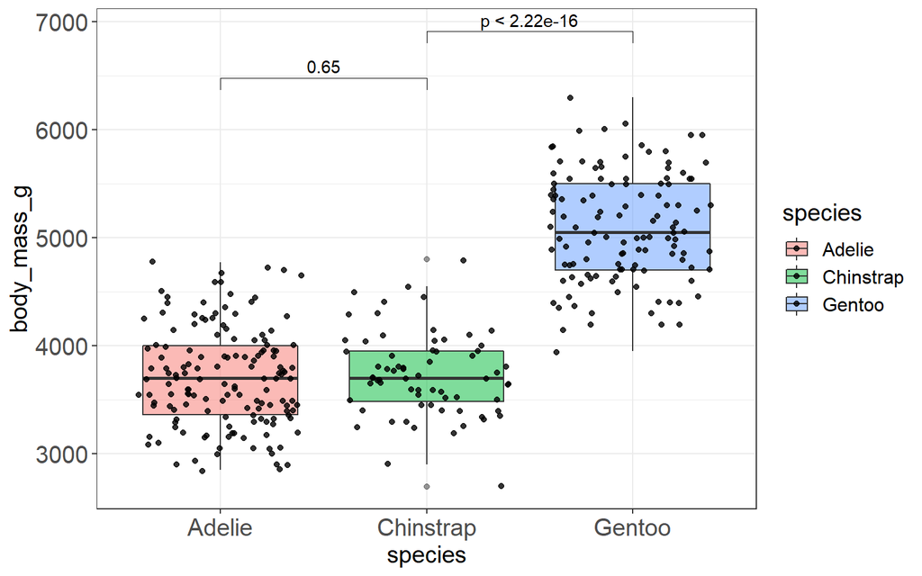

```r
# we can still do multiple t tests (but should really use a correction if we do this)
my_comparisons <- list(c("Adelie", "Chinstrap"), c("Chinstrap", "Gentoo")) # has to be in a list
plot_1b +
  stat_compare_means(comparisons = my_comparisons, method="t.test")
```

```r
# it's better if we do an anova

# Compute the analysis of variance
aov_1b <- aov(body_mass_g ~ species, data = penguins)
# Summary of the analysis
summary(aov_1b)
```

```
##              Df    Sum Sq  Mean Sq F value Pr(>F)
## species       2 145190219 72595110   341.9 <2e-16 ***
## Residuals   330  70069447   212332
## ---
## Signif. codes:  0 '***' 0.001 '**' 0.01 '*' 0.05 '.' 0.1 ' ' 1
```

```r
# other ways to do anova
# note slightly different results for welch's and fisher's
# "Welch’s ANOVA isn’t sensitive to unequal variances" https://statisticsbyjim.com/anova/welchs-anova-compared-to-classic-one-way-anova/
anovaOneW(formula = body_mass_g ~ species, data = penguins, fishers = TRUE) # jmv
```

```
##
##  ONE-WAY ANOVA
##
##  One-Way ANOVA
##  ------------------------------------------------------------------------
##                               F           df1    df2         p
##  ------------------------------------------------------------------------
##    body_mass_g    Welch's     316.5017      2    187.6778    < .0000001
##                   Fisher's    341.8949      2         330    < .0000001
##  ------------------------------------------------------------------------
```

```r
anova_test(penguins, body_mass_g ~ species) # rstatix
```

```
## ANOVA Table (type II tests)
##
##    Effect DFn DFd       F        p p<.05   ges
## 1 species   2 330 341.895 3.74e-81     * 0.674
```

```r
penguins %>% welch_anova_test(body_mass_g ~ species) # rstatix
```

```
## # A tibble: 1 x 7
##   .y.             n statistic   DFn   DFd        p method
## * <chr>       <int>     <dbl> <dbl> <dbl>    <dbl> <chr>
## 1 body_mass_g   333      316.     2  188. 7.44e-61 Welch ANOVA
```

# Example 2: are penguin bills length correlated with flipper length? (continuous and continuous)

### descriptive statistics

```r
penguins %>%
  summarise(across(contains("length"), mean)) %>%
  gt()
```

| bill_length_mm | flipper_length_mm |
| --- | --- |
| 43.99279 | 200.967 |

### visualization

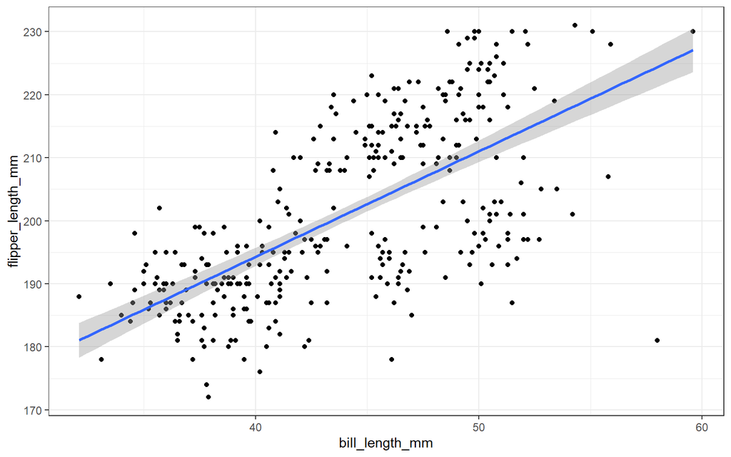

```r
ggplot(penguins, aes(bill_length_mm, flipper_length_mm)) +
  geom_point() +
  geom_smooth(method = "lm")
```

### statistics: correlation test

```r
cor(penguins$bill_length_mm, penguins$flipper_length_mm)
```

```
## [1] 0.6530956
```

```r
cor.test(penguins$bill_length_mm, penguins$flipper_length_mm)
```

```
##
##  Pearson's product-moment correlation
##
## data:  penguins$bill_length_mm and penguins$flipper_length_mm
## t = 15.691, df = 331, p-value < 2.2e-16
## alternative hypothesis: true correlation is not equal to 0
## 95 percent confidence interval:
##  0.5868092 0.7106869
## sample estimates:
##       cor
## 0.6530956
```

### ggpubr: color by species

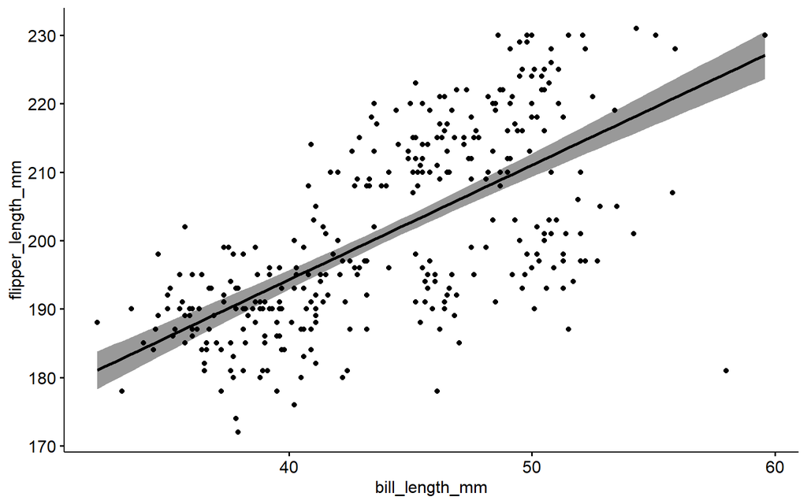

```r
ggscatter(penguins, x = "bill_length_mm", y = "flipper_length_mm",
          size=1.5,
          add = "reg.line", # Add regression line
          conf.int = TRUE # Add confidence interval
          )
```

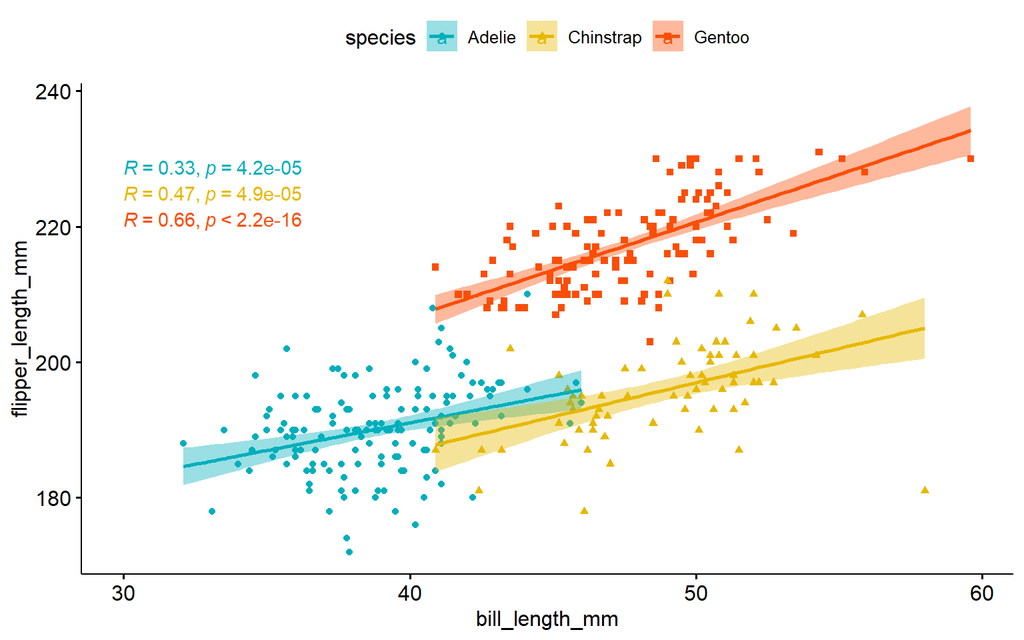

```r
ggscatter(penguins, x = "bill_length_mm", y = "flipper_length_mm",
          size=1.5,
          color = "species",
          shape = "species",
          palette = c("#00AFBB", "#E7B800", "#FC4E07"),
          add = "reg.line", # Add regression line
          conf.int = TRUE # Add confidence interval
          ) +
  stat_cor(aes(color = species), label.x = 30) # Add correlation coefficient (can add this line of code to regular ggplot too!)
```

# Example 3: Do the number of penguin species vary by year? (categorical and categorical)

```r
penguins
```

```
## # A tibble: 333 x 8
##    species island    bill_length_mm bill_depth_mm flipper_length_mm body_mass_g
##    <fct>   <fct>              <dbl>         <dbl>             <int>       <int>
##  1 Adelie  Torgersen           39.1          18.7               181        3750
##  2 Adelie  Torgersen           39.5          17.4               186        3800
##  3 Adelie  Torgersen           40.3          18                 195        3250
##  4 Adelie  Torgersen           36.7          19.3               193        3450
##  5 Adelie  Torgersen           39.3          20.6               190        3650
##  6 Adelie  Torgersen           38.9          17.8               181        3625
##  7 Adelie  Torgersen           39.2          19.6               195        4675
##  8 Adelie  Torgersen           41.1          17.6               182        3200
##  9 Adelie  Torgersen           38.6          21.2               191        3800
## 10 Adelie  Torgersen           34.6          21.1               198        4400
## # ... with 323 more rows, and 2 more variables: sex <fct>, year <int>
```

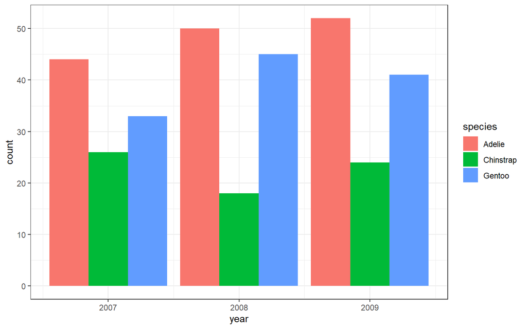

```r
# descriptive statistics
peng_table <- table(penguins$species, penguins$year)

# visualization
ggplot(penguins, aes(year, ..count..)) +
  geom_bar(aes(fill = species), position = "dodge")
```

```r
# chi squared test
chisq.test(peng_table)
```

```
##
##  Pearson's Chi-squared test
##
## data:  peng_table
## X-squared = 3.2711, df = 4, p-value = 0.5135
```

# ANOVA

https://towardsdatascience.com/doing-and-reporting-your-first-anova-and-ancova-in-r-1d820940f2ef

```r
penguins
```

```
## # A tibble: 333 x 8
##    species island    bill_length_mm bill_depth_mm flipper_length_mm body_mass_g
##    <fct>   <fct>              <dbl>         <dbl>             <int>       <int>
##  1 Adelie  Torgersen           39.1          18.7               181        3750
##  2 Adelie  Torgersen           39.5          17.4               186        3800
##  3 Adelie  Torgersen           40.3          18                 195        3250
##  4 Adelie  Torgersen           36.7          19.3               193        3450
##  5 Adelie  Torgersen           39.3          20.6               190        3650
##  6 Adelie  Torgersen           38.9          17.8               181        3625
##  7 Adelie  Torgersen           39.2          19.6               195        4675
##  8 Adelie  Torgersen           41.1          17.6               182        3200
##  9 Adelie  Torgersen           38.6          21.2               191        3800
## 10 Adelie  Torgersen           34.6          21.1               198        4400
## # ... with 323 more rows, and 2 more variables: sex <fct>, year <int>
```

```r
mydata <- iris

# test assumption of homogeneity of variance
library(car)
leveneTest(bill_length_mm~species,penguins) # came back insignificant which is good. This means the variance between bill length and species is not significantly different so we can move forward. does not violate assumption of homogeneity of variance
```

```
## Levene's Test for Homogeneity of Variance (center = median)
##        Df F value Pr(>F)
## group   2  2.2855 0.1033
##       330
```

```r
anova_results = aov(bill_length_mm ~ species, penguins)
summary(anova_results)
```

```
##              Df Sum Sq Mean Sq F value Pr(>F)
## species       2   7015    3508   397.3 <2e-16 ***
## Residuals   330   2914       9
## ---
## Signif. codes:  0 '***' 0.001 '**' 0.01 '*' 0.05 '.' 0.1 ' ' 1
```

```r
library(psych)
describeBy(penguins$bill_length_mm, penguins$species)
```

```
##
##  Descriptive statistics by group
## group: Adelie
##    vars   n  mean   sd median trimmed  mad  min max range skew kurtosis   se
## X1    1 146 38.82 2.66  38.85   38.78 2.97 32.1  46  13.9 0.15    -0.22 0.22
## ------------------------------------------------------------
## group: Chinstrap
##    vars  n  mean   sd median trimmed  mad  min max range  skew kurtosis  se
## X1    1 68 48.83 3.34  49.55   48.91 3.63 40.9  58  17.1 -0.09    -0.14 0.4
## ------------------------------------------------------------
## group: Gentoo
##    vars   n  mean   sd median trimmed  mad  min  max range skew kurtosis   se
## X1    1 119 47.57 3.11   47.4   47.45 3.11 40.9 59.6  18.7  0.6     1.07 0.28
```

## Report ANOVA results

We observed differences in bill lengths between the three species of Adelie (M=38.82), Chinstrap (M=48.83), and Gentoo (M=47.57). An ANOVA showed that these differences between species were significant, i.e. there was a significant effect of the species on the bill length of the penguins, F(2,330)=397.3, p<.001.

# ANCOVA

```r
ancova_results=aov(bill_length_mm ~ species+sex, penguins) # controlling for body sex

# summary function won't work here
Anova(ancova_results, type="III")
```

```
## Anova Table (Type III tests)
##
## Response: bill_length_mm
##             Sum Sq  Df  F value    Pr(>F)
## (Intercept) 138770   1 25680.31 < 2.2e-16 ***
## species       6976   2   645.44 < 2.2e-16 ***
## sex           1136   1   210.17 < 2.2e-16 ***
## Residuals     1778 329
## ---
## Signif. codes:  0 '***' 0.001 '**' 0.01 '*' 0.05 '.' 0.1 ' ' 1
```

## Report ANCOVA results

The covariate, sex, was significantly related to the penguins’ bill length, F(1,329)=210.17, p<.001. There was also a significant effect of the species of the penguins on the bill length after controlling for sex, F(2,329)=645.44, p<.001.

# linear regression

lm([target variable] ~ [predictor variables], data = [data source])

```r
lm_penguin = lm(bill_length_mm~body_mass_g , data = penguins) #Create the linear regression
summary(lm_penguin)
```

```
##
## Call:
## lm(formula = bill_length_mm ~ body_mass_g, data = penguins)
##
## Residuals:
##      Min       1Q   Median       3Q      Max
## -10.1652  -3.0664  -0.7672   2.2356  16.0371
##
## Coefficients:
##              Estimate Std. Error t value Pr(>|t|)
## (Intercept) 2.715e+01  1.292e+00   21.02   <2e-16 ***
## body_mass_g 4.003e-03  3.016e-04   13.28   <2e-16 ***
## ---
## Signif. codes:  0 '***' 0.001 '**' 0.01 '*' 0.05 '.' 0.1 ' ' 1
##
## Residual standard error: 4.424 on 331 degrees of freedom
## Multiple R-squared:  0.3475, Adjusted R-squared:  0.3455
## F-statistic: 176.2 on 1 and 331 DF,  p-value: < 2.2e-16
```

https://www.statsimprove.com/en/what-is-the-difference-between-anova-and-regression-and-which-one-to-choose/

# Group 2

- trouble reproducing Study 2 Empathy Physical Distancing plot

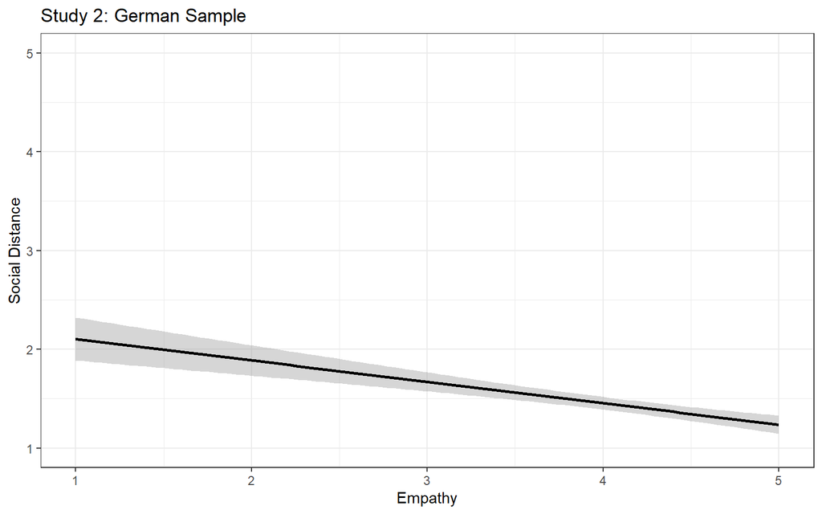

```r
group2 <- read_excel(here("data", "3_pfattheicher", "Study2.xlsx"))

fig1 <- group2 %>%
  rowid_to_column("ID") %>%
  select(ID, ve, sd, sdR)

# raw data, this doesn't have any values recoded
ggplot(fig1, aes(x=ve, y=sd)) +
  geom_smooth(method = "lm", colour = "black", se = TRUE) +
  theme_bw() +
  ylim(1,5) +
  labs(title = "Study 2: German Sample",
       x = "Empathy",
       y = "Social Distance")
```

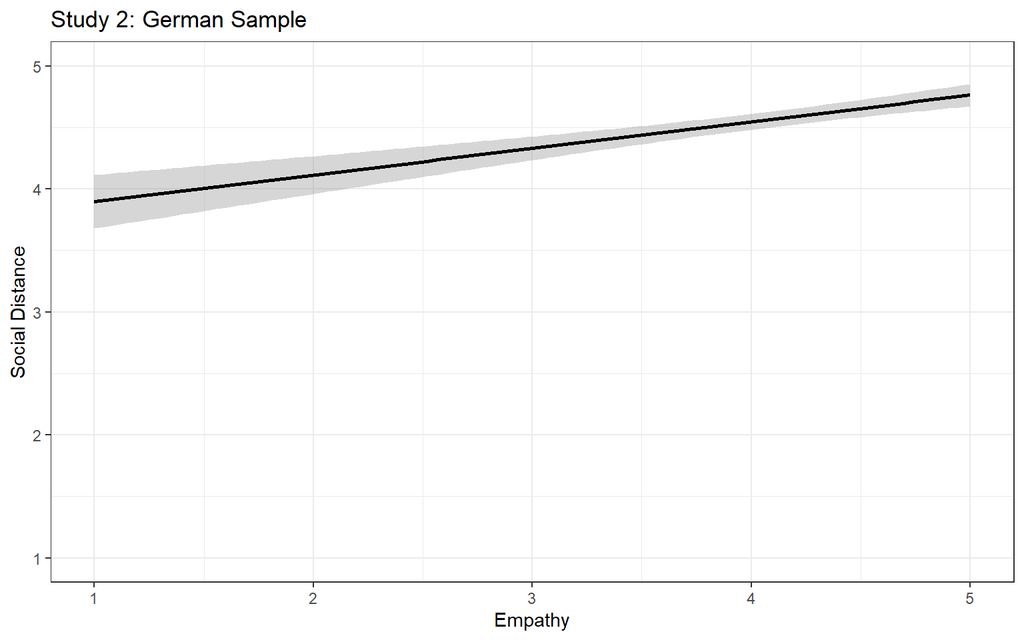

```r
# there's actually another variable sdR that already accounts for the reverse coding
ggplot(fig1, aes(x=ve, y=sdR)) +
  geom_smooth(method = "lm", colour = "black", se = TRUE) +
  theme_bw() +
  ylim(1,5) +
  labs(title = "Study 2: German Sample",
       x = "Empathy",
       y = "Social Distance")
```